# Political Economy and the Promise and Limits of (Green) Industrial Policy

Paul Heideman

2023-05-27

# The Big Questions

- What has the path of global capitalism been over the last half century or so?
  - Have we been in a period of stagnation? Or a period of growth?
  - What’s happening to the working class? How has it changed?

### One Answer: Robert Brenner and the Long Downturn

- Robert Brenner, a Marxist economic historian, argues that since the 1970s the capitalist world has been mired in crisis.
  - This crisis is rooted in persistent overcapacity in manufacturing, which has driven down profitability in that sector and dragged down the economy has a whole.
  - This doesn’t mean there’s constant economic crisis. Rather, it means that the kind of coordinated growth we saw during the “golden age” of postwar capitalism, where all major economies are growing at once, isn’t possible. Instead, national economies can only grow by squeezing out their rivals.
- This account has been particularly influential with sections of the ultra-left (California insurrectionists) as well as the broader *New Left Review* milieu.
  - For some, Brenner’s account is proof of the exhaustion of reformism. Attempts to win reforms are pointless because the long downturn means capitalists have no room for compromise, and will fight reforms with the same intensity they’d fight revolution.

# The Big Picture

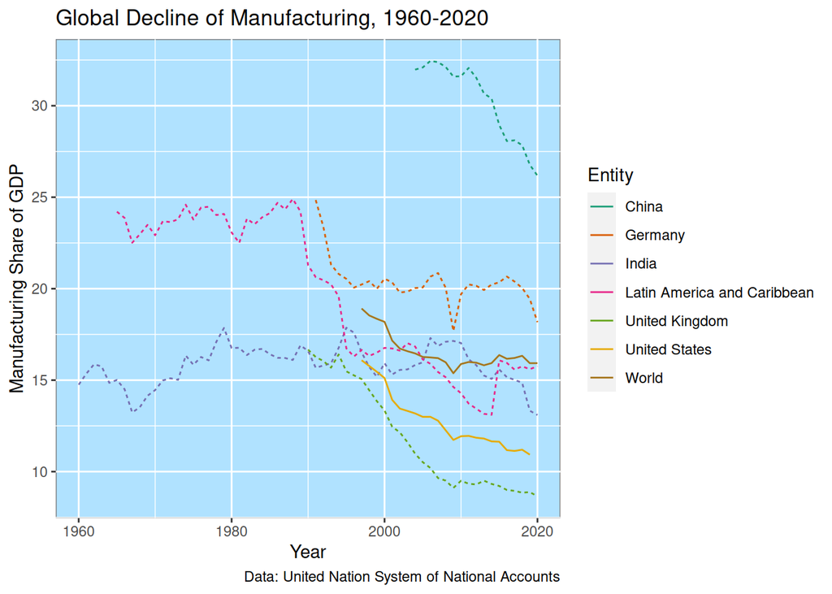

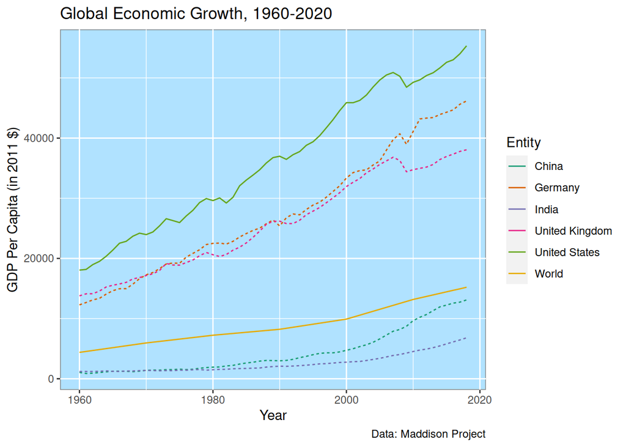

### Some Thoughts

- It’s *prima facie* implausible that the same dynamics the caused crisis in the 1970s are causing crisis in the global economy today.
- Brenner’s picture grows even more implausible given the decline of manufacturing in the global economy. It seems very unlikely that a sector comprising ~10% of the the US economy is determining the economy’s trajectory.
- In general, I think we should be wary of basing our politics on on one hyper-specific analysis of the global economy.

# The Question of Economic Policy Regimes

- The question of how to characterize and explain economic policy is closely related to, but distinct from, the question of how to characterize and explain the global economy.
- Neoliberalism is best thought of as a kind of economic policy (as well as the associated justifications for that policy).
  - As policy, neoliberalism generally includes some combination of budgetary austerity, privatization, deregulation, and tax cuts.
  - While there’s obviously something to this, it’s also important not to underestimate the durability of the welfare state.

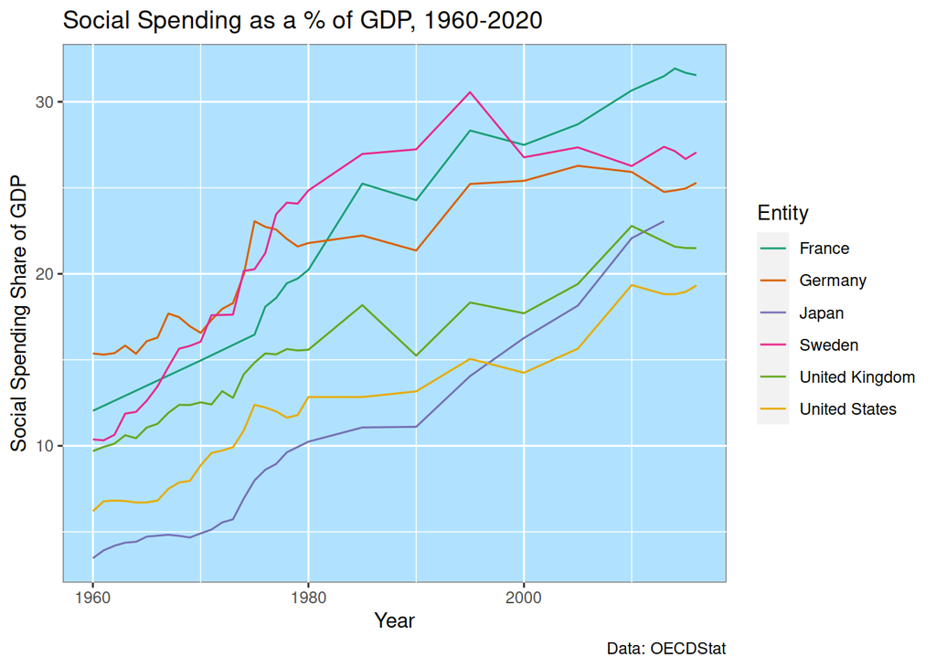

## More Questions

- One of the biggest questions for the left today in the United States is if neoliberalism is in fact ending. In other words, has there been a fundamental reorientation in American economic policy?
- Additionally, is this reorientation, assuming it exists, good? Or is it a reorientation still fundamentally tethered to capitalist interests that offers little for workers?
- If there has been a reorientation, what does this tell us about the Democratic Party?